# 52414 - lab 1 Solutions

Aviad Elron and Jonathan Bublil

6/4/2022

# *Lab 1: Basic Data Wrangling and Plotting, Distributions*

### Submission Instructions

This lab will be submitted in pairs using GitHub (if you don’t have a pair, please contact us).  
Please follow the steps in the [GitHub-Classroom Lab 1](https://classroom.github.com/a/4PpjneTd) to create your group’s Lab 1 repository.  
**Important: your team’s name must be `FamilyName1_Name1_and_FamilyName2_Name2`**.  
You can collaborate with your partner using the `git` environment; You can either make commits straight to the main repository, or create individual branches (recommended). However, once done, be sure to merge your branches to master - you will be graded using the most recent master version - your last push and merge before the deadline of May 15th.  
**Please do not open/review other peoples’ repositories - we will be notified by GitHub if you do.**

Your final push should include this Rmd file (with your answers filled-in), together with the html file that is outputted automatically by knitr when you knit the Rmd. Anything else will be disregarded. In addition, please adhere to the following file format:  
`Lab_1_FamilyName1_Name1_and_FamilyName2_Name2.Rmd/html`

The only allowed libraries are the following (**please do not add additional libraries without permission from the course staff**):

## Analysis of the World Covid-19 Dataset

The `world-of-data` website hosts world-wide epidemiological data on the Corona Virus (COVID-19). The dataset is compiled by the Johns Hopkins University Center for Systems Science and Engineering (JHU CCSE) from various sources, and follows The dataset contains data since January 2020. For the data and more information about it, please visit [here](https://github.com/owid/covid-19-data/tree/master/public/data).

You can see several nice visualizations of the data [here](https://ourworldindata.org/covid-vaccinations)

we will focus on analyzing the Covid-19 cases, deaths and vaccinations data over time for different countries and continents.

### General Guidance

- Your solution should be submitted as a full Rmd report integrating text, code, figures and tables. For each question, describe first in the text of your solution what you’re trying to do, then include the relevant code, then the results (e.g. figures/tables) and then a textual description of them.
- In most questions the extraction/manipulation of relevant parts of the data-frame can be performed using commands from the `tidyverse` and `dplyr` R packages, such as `head`, `arrange`, `aggregate`, `group-by`, `filter`, `select`, `summaries`, `mutate`, `order` etc.
- When displaying tables, show the relevant columns and rows with meaningful names, and describe the results.
- When displaying figures, make sure that the figure is clear to the reader, axis ranges are appropriate, labels for the axis , title and different curves/bars are displayed clearly (font sizes are large enough), a legend is shown when needed etc. Explain and describe in text what is shown in the figure.
- In many cases, data are missing (e.g. `NA`). Make sure that all your calculations (e.g. taking the maximum, average, correlation etc.) take this into account. Specifically, the calculations should ignore the missing values to allow us to compute the desired results for the rest of the values (for example, using the option `na.rm = TRUE`).
- Grading: There are $10$ questions overall. Each question is worth $10$ points for the lab grade. The questions vary in length and difficulty level. It is recommended to start with the simpler and shorter questions.

### Questions:

1. **Loading data and basic processing:**
   1. Load the complete covid19 dataset in `csv` format from [world-of-data](https://github.com/owid/covid-19-data/tree/master/public/data) into a data-frame in `R`.  
      Change if needed the class of the `date` variable to `Date` and check that the class is correct.
   2. List in a table the top five *dates* in terms of number of `new_cases` for `High income` countries. Show only the date and the number of new cases at this date.  
      Repeat the same with two additional separate tables for top five dates for `new_deaths` and `new_vaccinations`.
2. **Comparing low vs. high income countries:**
   1. Write a function that receives as input the data-frame, and a column name as string. The function plots the value of the input column as a function of the date for both `High income` and `Low income` countries, shown on the same graph with different colors or symbols. Use meaningful axis and plot labels, and add an informative legend. `NA` or other no-number values should not be displayed.
   2. Use the function written in (a.) and plot of the number of `new_cases_per_million` vs. date for the high vs. low income countries. Next, make a similar plot for the *log* of the *smoothed* number of new cases per million, `new_cases_smoothed_per_million`. Which plot is easier to interpret? explain.  
      Similarly, make two additional separate plots for the *log* of the *smoothed* number of new deaths and new vaccinations per million as a function of date for the high vs. low income countries. Describe the plotted results.
3. **Storing and analyzing current (cumulative) values:**
   1. Create a new data-frame called `current` with *one row per country* (and other locations), that for each country will store as columns the country name (`location`) and `continent`, and also the **current** values (latest date reported for each value) for: `total_cases_per_million`, `total_deaths_per_million`, `total_vaccinations_per_hundred`, `people_fully_vaccinated_per_hundred`, `total_boosters_per_hundred` and `excess_mortality_cumulative_per_million`.
   2. Show the values for the current `total_deaths_per_million` in different countries in a histogram with 30 bins. Does this histogram look close to the normal distribution? Compute the *skewness* and *kurtosis* for this distribution, and explain what they mean about the empirical distribution of the data.
   3. Next, make a scatter plot showing the current `total_deaths_per_million` (y-axis) vs. the current `total_cases_per_million`. Compute a linear regression line of the total number of deaths per million as a function of the total number of cases per million and add the fitted regression line to the plot. What is the slope and what does it represent?
4. **Vaccinations in different continents:**
   1. For each of the six different continents (`Africa`, `Asia`, `Europe`, `North America`, `Oceania`, `South America`), make a boxplot of the distribution of the (current) total number of vaccinations per hundred in all the countries in the continent. Show one figure with the six boxplots next to each other. (Use the new `current` data-frame created in qu. 3). Find two outlier countries (can be of any continent) and write their name and value.
   2. Define (for the original data-frame from qu. 1) a new column called `booster_ratio`, that lists for each date the fraction of individuals that got a third, booster shot in a country (`total_boosters`), out of all individuals that got two shots (`people_fully_vaccinated`), by dividing the two columns (if either of them is `NA` or if the denominator is zero, set `booster_ratio` to `NA`). Plot the `booster_ratio` as a function of time for the six continents (on the same plot, using different colors) and describe the results.
5. **Displaying monthly data:**
   1. For each month from January 2020 until March 2022 compute the total number of new cases per million in this month for each country individually (around 230 numbers for each month), and make a boxplot representing the empirical distribution fo these ~230 values. Show the boxplots for all months in one plot together in a chronological order, from left to right.

      *Guidance:* (i) Beware to not double-count cases/deaths/vaccinations. (ii) Treat each month separately (e.g. March 2020 and March 2022 are different).
   2. Repeat (a.), but this time with the total number of `new_deaths` and `new_vaccinations` for each month (two separate plots).

      What can you conclude about the pandemic at different periods from these plots? describe the results for each of the three plots in 2-3 sentences.
6. **R - disease reproduction number:** Add to the covid data-frame a new column called `R_cases`, defined for `location` and `date` as the number of `new_cases_smoothed` at this date, divided by the value of the same variable seven days before (if the value seven days before is zero or not defined, define `R_cases` at the current date to be `NA`). This column represents roughly the expected number of people that each case infects, and determines the spread of the disease, with values above (below) one indicating that the disease is spreading (declining).

   Plot the `R_cases` value as a function of time for `Israel`, `United Kingdom` and `United States`, and describe the results.  
   List in a table the number of days at which the disease was spreading (value above 1) in each of the three countries.
7. **Displaying data on the world map:** Use the `rworldmap` package to display the world map and color each country based on the `total_deaths_per_million`. Repeat for `total_vaccinations_per_hundred`, and `excess_mortality_cumulative_per_million`. Describe the resulting maps in a couple of sentences.

   List the top three countries for each of these variables in a table.

   **Guidance:** Use the `joinCountryData2Map` and `mapCountryData` commands to make the plots. Keep countries with missing data in white.
8. **Cross correlations and delay from diagnosis to death:** We want to use the data and *cross-correlation* in order to study the typical *time delay* between *diagnosis* of Covid-19 and *death* from Covid-19 for cases not surviving the disease. For two functions of time $X(t)$ and $Y(t)$ (here $t$ is discrete, representing for example days) we define their *cross-correlation* at time-delay $\Delta_t$ as follows: $cross_{corr}(\Delta_t ; X, Y) = Corr(X(t), Y(t+\Delta_t))$.  
   That is, the cross-correlation function at the time-delay $\Delta_t$ for two vectors of length $n$ is obtained by computing the Pearson correlation coefficient of the vector $X[1,...,n-\Delta_t]$ with the vector $Y[\Delta_t+1,...,n]$, for $\Delta_t>0$. For $\Delta_t < 0$ we replace the role of $X$ and $Y$ in this formula.
   1. Write a function that receives as input the data-frame, a country name and the name of two columns, and computes the value of their cross-correlation in this country for time delay of up to two months apart, that is for all values of $\Delta_t$ between $-60$ days and $60$ days. The function should return a vector of length $121$ representing these correlations. *Do not* use available cross-correlation functions in $R$, but write the function yourself.
   2. Use the function from (a.) to compute the cross correlation between the number of `new_cases_smoothed` and `new_deaths_smoothed` for the entire *World*, and plot it as a function of $\Delta_t$. At what time delay is the cross correlation maximized? what is your interpretation of this time-delay?
9. **Death risk after Covid-19 infection:**
   1. Add to the main covid data-frame a new column called `death_rate`, defined for each `location` and `date` as the number of `total_deaths` divided by the number of `total_cases`. This column represents the risk of a person diagnosed with covid to die from the disease. Plot for each of the six continents and the entire world the `death_rate` as a function of time (one plot with separate colors/symbols). Since there is a delay from time of diagnosis to time of death, the initial values of this column are less reliable as a measure of death risk, hence start your plot on *January 1st, 2021*. Do we see a decrease in the risk over time? can you suggest explanations for the observed trends?
   2. Make a similar plot for all continents and the world, but for the `total_vaccinations_per_hundred` variable. Do the plots suggest that the change in risk is correlated to the change in the number of vaccinations?
10. **Excess mortality:** It is claimed that in some countries the death-rate from Covid-19 is under-reported. We can investigate this using excess mortality data - this data lists the number of deaths from all causes at each country, compared to the usual number of deaths at the same country and date calculated from previous years mortality data. The gap between the two, representing and increase (or decrease) in deaths beyond the usual rate, is called ‘excess mortality’, and might be partially or fully explained by deaths from Covid-19.
    1. Use the `current` data-frame to make a scatter plot of the current date `total_deaths_per_million` vs. the `excess_mortality_cumulative_per_million` for all countries for which excess mortality data is available. Add the lines $y=x, y=x+2000$ and $y=x-2000$ to the plot. Mark on the graph in a different color all the countries for which the difference between the the excess mortality and the covid death rate (per million) is at least 2000 and add their names to the plot (you can use the `text` function).
    2. Pick three countries where the excess mortality was at least 2000 per million *above* the covid death rate, and that have at least $50$ available data points for each for `excess_mortality_cumulative_per_million`. Use the main covid data-frame to plot as a function of time both the `total_deaths_per_million` and the `excess_mortality_cumulative_per_million` for each country (one plot - use different colors/symbols). Identify from the plot for each country the time periods where most deaths not explained by Covid-19 occurred.

**Solution:**

```r
library(tidyverse) # This includes dplyr, stringr, ggplot2, ..
library(data.table)
library(rworldmap) # world map
library(ggthemes)
library(reshape2) # melt: change data-frame format long/wide
library(e1071) # skewness and kurtosis
library(ggrepel)
```

1. In the first question we were asked to load the dataset and work some basic frequancy functions on it. So we first loaded the covid19 dataset:

```r
df = read.csv("owid-covid-data.csv")
df$date = as.Date(df$date)  #made sure that the date column is classified as "date" variable.
```

And then we rearranged the dataframe in order to be able to create tables that displays the dates with the most new cases for high income countries:

```r
filtered_by_income <- df[which(df$location=='High income'),]
filtered_by_income_ord1 <-  head(filtered_by_income[order(filtered_by_income$new_cases,decreasing = TRUE),],5) # Ordering by decreasing Value
new_cases_table <- data.frame(
                 date=filtered_by_income_ord1$date,
                 new_cases=filtered_by_income_ord1$new_cases)
new_cases_table
```

```
##         date new_cases
## 1 2022-01-19   2830533
## 2 2022-01-18   2737804
## 3 2022-01-10   2589365
## 4 2022-01-21   2558959
## 5 2022-01-26   2532201
```

```r
filtered_by_income_ord2 <-  head(filtered_by_income[order(filtered_by_income$new_deaths ,decreasing = TRUE),],5)
new_deaths_table <- data.frame(
                 date=filtered_by_income_ord2$date,
                 new_deaths=filtered_by_income_ord2$new_deaths)
new_deaths_table
```

```
##         date new_deaths
## 1 2021-01-20      11047
## 2 2021-01-26      10279
## 3 2021-01-12      10170
## 4 2021-01-27      10079
## 5 2021-01-08       9967
```

```r
filtered_by_income_ord3 <-  head(filtered_by_income[order(filtered_by_income$new_vaccinations ,decreasing = TRUE),],5)
new_vaccinations_table <- data.frame(
                 date=filtered_by_income_ord3$date,
                 new_vaccinations=filtered_by_income_ord3$new_vaccinations)
new_vaccinations_table
```

```
##         date new_vaccinations
## 1 2021-08-04         11980956
## 2 2021-12-17          9749888
## 3 2021-06-10          9539198
## 4 2021-06-11          9505657
## 5 2021-06-09          9452950
```

2. In the second question we were requested to create a comparison function and use it on diffrenet varibles in order to analyze differences between high and low income countries. We started this question by writing the requested function: a function that compares between the high income countries and the low income countries by visualaizing the diffrences in a given variable using a plot:

```r
  compare <- function(df,col_name){
  df_sorted <- subset(df, location == c("High income", "Low income"), is.na(date) == FALSE
  , is.na(col_name) == FALSE)       # creating new data frame which contains only the rows with "low income" or "high income" as their location.
  ggplot1 <- ggplot(data = df_sorted, aes_string(y=col_name, x="date",
  colour = "location", group = "location")) + geom_line() + xlab("date") +
  ylab(col_name)      # creating the plot which visualizing the diffrences.
  return (ggplot1)
}
```

We then used the function we created in a, to compare diffrenet variables:

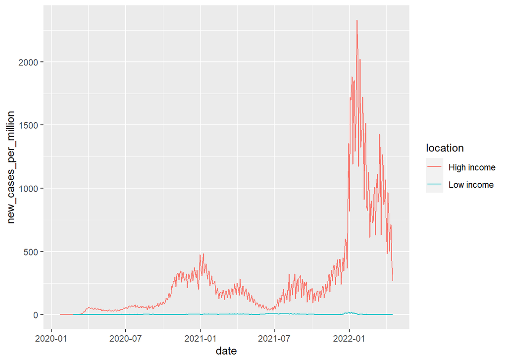

```r
compare(df, "new_cases_per_million")
```

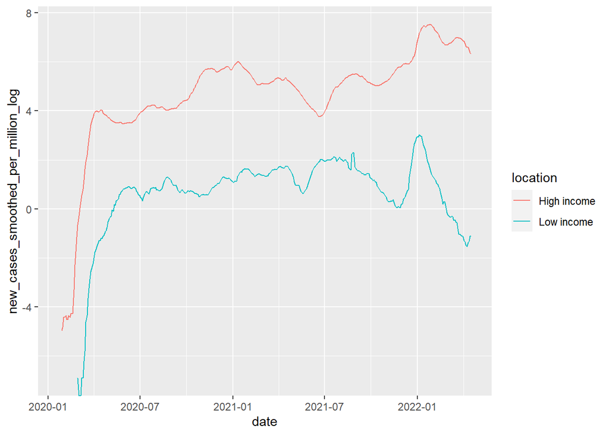

```r
df$new_cases_smoothed_per_million_log=log(df$new_cases_smoothed_per_million)    # creation of a logarithmic variable
compare(df, "new_cases_smoothed_per_million_log")
```

We can see that the smoothed log graph is easier to interpret. While using the logarithmic of a function(or a plot), we are keeping the overall appereance of this function, but on a much smaller scale: while on the original plot small differences on a large scale are not shown, on the the logarithmic plot we can actually notice and interpret them fairly easily.

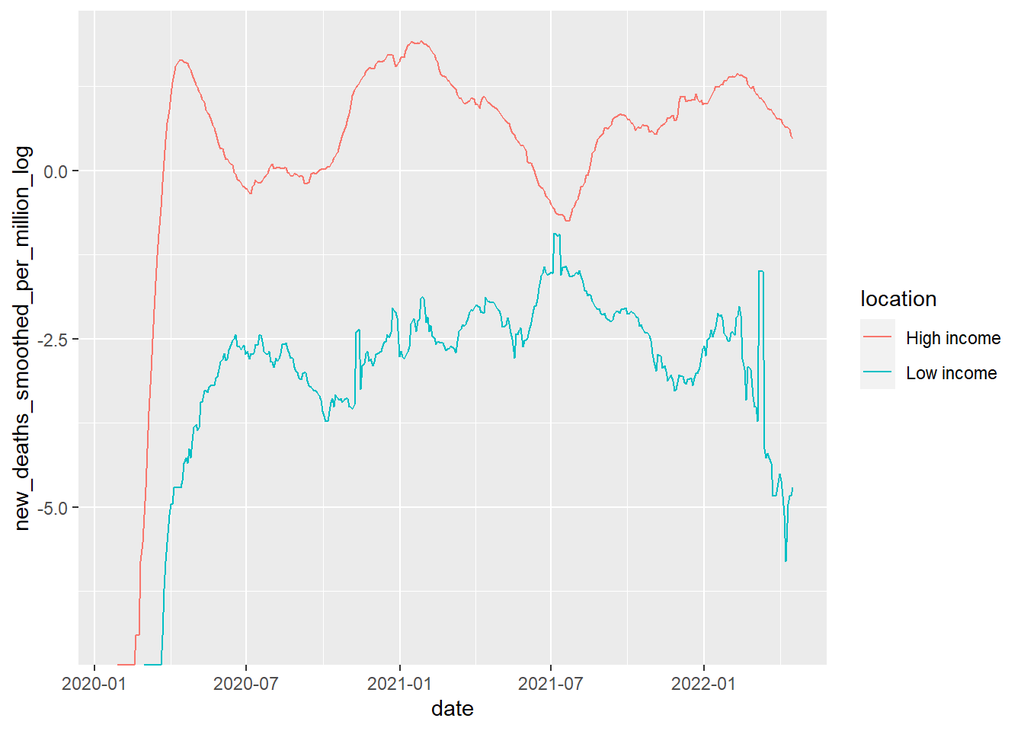

```r
df$new_deaths_smoothed_per_million_log=log(df$new_deaths_smoothed_per_million)
df$new_vaccinations_smoothed_per_million_log=log(df$new_vaccinations_smoothed_per_million)
compare(df, "new_deaths_smoothed_per_million_log")
```

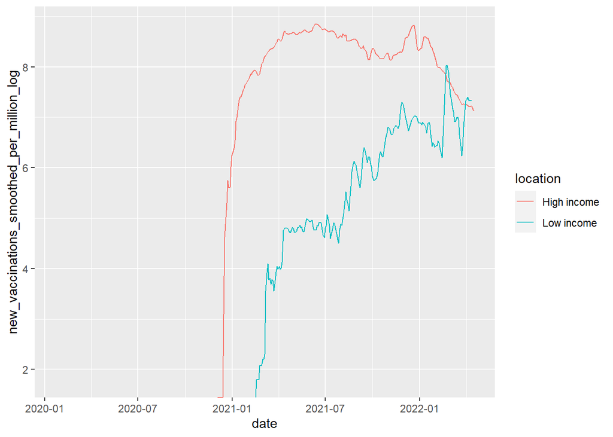

```r
compare(df, "new_vaccinations_smoothed_per_million_log")
```

We can see in the graphs, that the numbers of the high income countries both in new deaths and in new vaccinations are bigger. we can conclude from the graphs that the tracking of new cases and number of deaths caused by the corona virus is inferior in comparsion to the high income countries due to lack of resources. Due the same reasons we can explain the differences in the number of new vaccination/million: high income countries can buy more vaccines, and when the supply is big enough and all the high income countries have purchased enough vaccines, then the lower income countries could afford to buy them as well (we also know that some of the lower income countries got their vaccines only because of the financel help of rich countries).

3. In this question we are requested to make a new dataframe with the current values of each country and continent and analyze it.

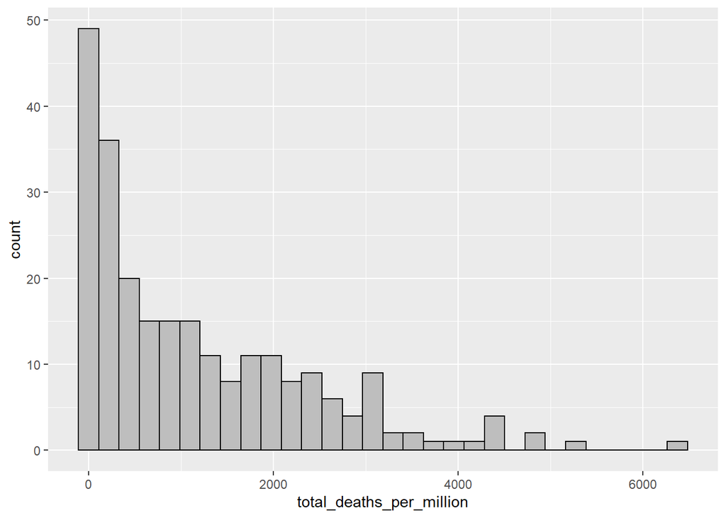

```r
#making new dataframe and filling the NA's with the most recent values
current = df %>% fill(total_cases_per_million, total_deaths_per_million, total_vaccinations_per_hundred,
                          people_fully_vaccinated_per_hundred, total_boosters_per_hundred, excess_mortality_cumulative_per_million)
#selecting only the needed columns
current = subset(current, select=c(iso_code, location, continent, iso_code, total_cases_per_million, total_deaths_per_million, total_vaccinations_per_hundred,
                         people_fully_vaccinated_per_hundred, total_boosters_per_hundred, excess_mortality_cumulative_per_million))
#Leaving only row per country and continent
current = current[!duplicated(current$location, fromLast = TRUE),]
current %>% ggplot(aes(total_deaths_per_million)) + geom_histogram(bins=30, fill="gray", color="black", main="distribution of total deaths per million", xlab="current total deaths per million")
```

```r
skewness(current$total_deaths_per_million)
```

```
## [1] 1.295316
```

```r
#postivie skewnes (1.295316) means a long right tail
kurtosis(current$total_deaths_per_million)
```

```
## [1] 1.509454
```

```r
#positive kurtosis (1.509454) indicates how long the tail is compared to normal
```

from the histogram we see that the distribution is from exponential family. The postivie skewnes (1.295316) means a long right tail, positive kurtosis (1.509454) indicates how long the tail is compared to normal based on this graph, we can understand that the “Corona” virus isn’t deadly in comparison to other pandemics, most of the countries have small number of deaths/million.

```r
#Making the resgressiong model
reg = lm(current$total_deaths_per_million ~ current$total_cases_per_million)
print(reg)
```

```
##
## Call:
## lm(formula = current$total_deaths_per_million ~ current$total_cases_per_million)
##
## Coefficients:
##                     (Intercept)  current$total_cases_per_million
##                       6.183e+02                        4.053e-03
```

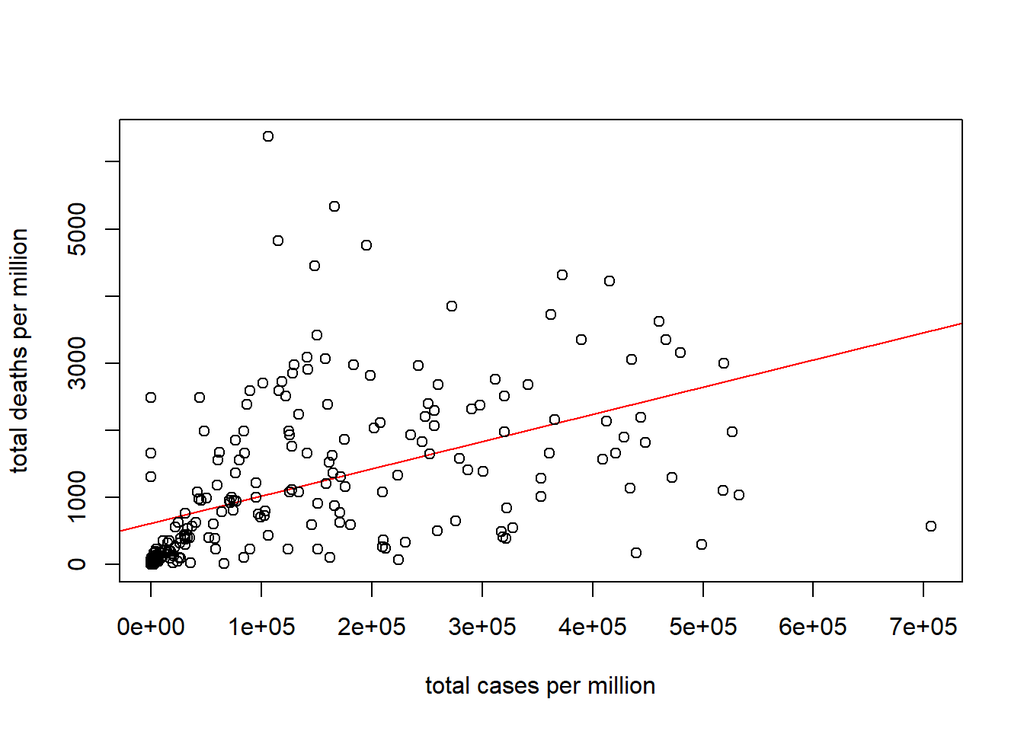

```r
plot(current$total_cases_per_million, current$total_deaths_per_million, xlab="total cases per million", ylab="total deaths per million", abline(reg, col="red"))
```

The value of the coefficient describing the effect of total cases per million on the number of deaths per million is 0.004053, so we can understand that the overall mortality rate is about 0.405$.

4. In question number 4 we are requested to make a boxplot graph of the distribution of the total vaccinations per hundred for each continent, and identify two outliers. Than we are asked to calculate the booster ratio of each country and analyze it using a graph.

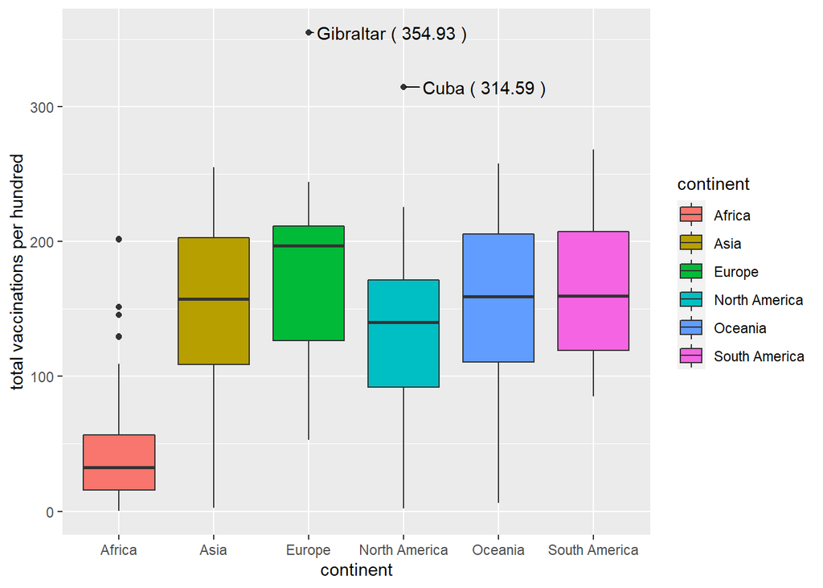

```r
#First we detect the top outliers
top_outliers = current$location[with(current, order(-total_vaccinations_per_hundred))][1:2]
#Now the plot, leaving only the countries
current %>% filter(!(is.na(current$continent) | current$continent=="")) %>% ggplot(aes(continent, total_vaccinations_per_hundred, fill=continent)) + geom_boxplot() + geom_text_repel(data=. %>% filter(location %in% top_outliers),aes(label=(paste(location,"(",total_vaccinations_per_hundred,")")), y=total_vaccinations_per_hundred), nudge_x = 0.85, min.segment.length = 0) + ylab("total vaccinations per hundred")
```

```r
#A function the prints the outliers
print(paste(paste("As we marked, the two outliers are",top_outliers[1],"With value of",current$total_vaccinations_per_hundred[current$location == top_outliers[1]]),paste(",and",top_outliers[2],"With value of",current$total_vaccinations_per_hundred[current$location == top_outliers[2]])))
```

```
## [1] "As we marked, the two outliers are Gibraltar With value of 354.93 ,and Cuba With value of 314.59"
```

A: As we marked on the graph, there are two outliers that have the maximum values and are gibralter with 354.93 vaccinations per hundred people, and cuba with 314.59.

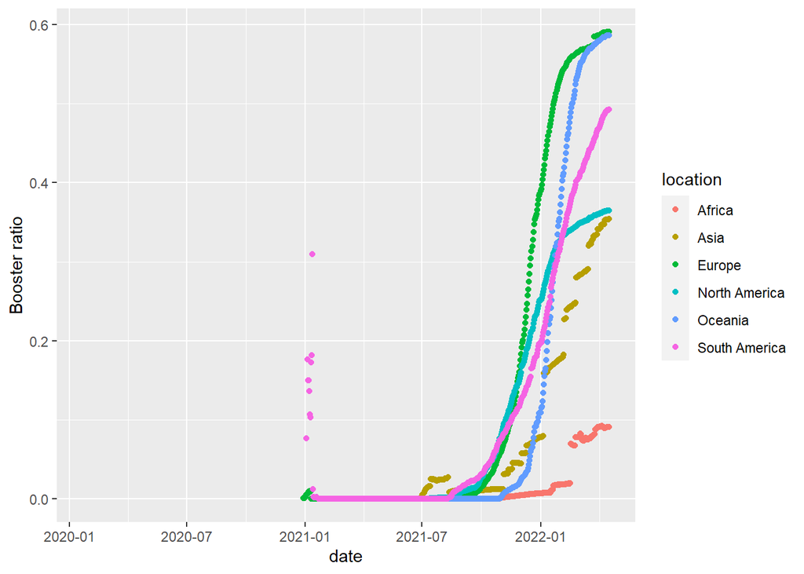

```r
#Calculating booster ratio
for(i in 1:length(df$total_boosters)){
  if(is.na(df$total_boosters[i] || is.na(df$people_fully_vaccinated[i]) || df$people_fully_vaccinated==0)){
    df$booster_ratio=NA
  }
  else{
    df$booster_ratio = df$total_boosters/df$people_fully_vaccinated
  }
}
#Now the plot of the booster ratio for each continent
df %>% filter(location %in% c("Asia", "Africa", "Europe", "North America", "Oceania", "South America")) %>% ggplot(aes(date, booster_ratio, colour=location)) + geom_point() + ylab("Booster ratio")
```

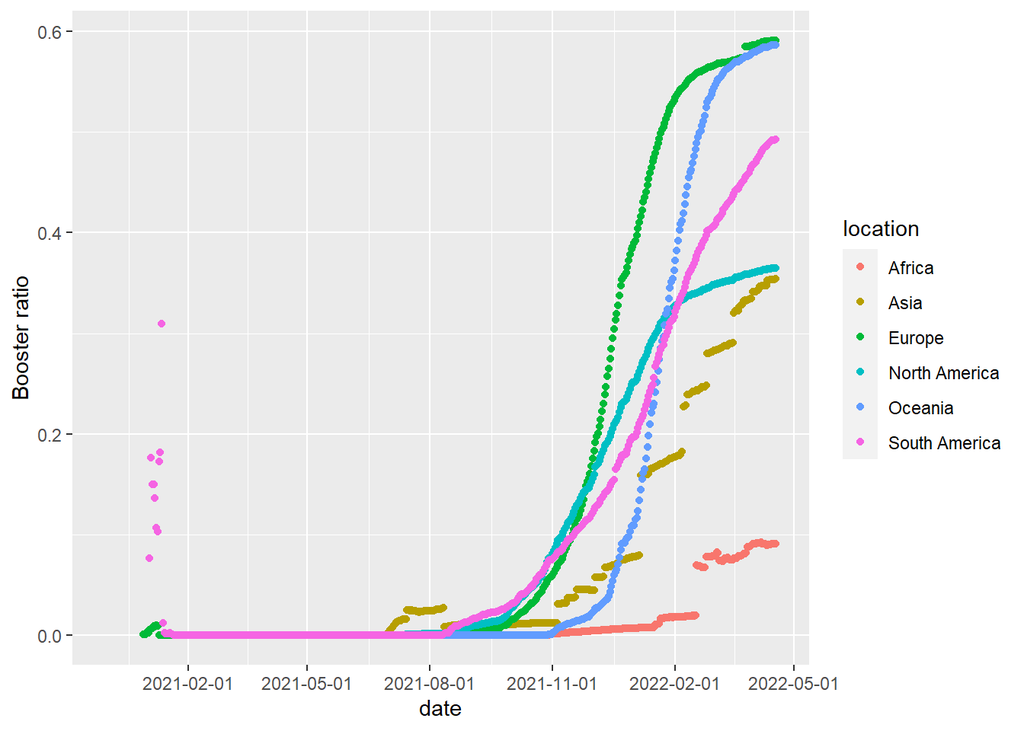

```r
#Since in the beginning there were no boosters, here is a better plot
#more accurate:
df %>% filter(location %in% c("Asia", "Africa", "Europe", "North America", "Oceania", "South America")) %>% filter(date>="2020-12-01") %>% ggplot(aes(date, booster_ratio, colour=location)) +  geom_point() + scale_x_date(date_breaks="3 months") + ylab("Booster ratio")
```

b: There is a sharp increase in the number of booster vaccinated people that started around october 2021, when we combine this data with the fact that the booster vaccination started around Augost-September 2021, we can also understand why: Most countries prioritize the elders and risk groups, so durning the first couple months, most of the population couldn’t get the vaccine even if they wanted to.

5. In this question we were requested to create a box plot graph that visualize the empirical distribution of diffrenet variables durning the period between January 2020 and March 2022. We first created new data-frames so we’ll be able to apply the necessary functions in order to get the requested plots:

```r
df$Month_Yr <- format(as.Date(df$date), "%Y-%m")   #created new date variable that contains only the month and year values for each row
df_q5 <- subset(df, date>as.Date("2020-01-01") & date<as.Date("2022-04-01"))  #keept only the requested dates
df_q5 <- group_by(df_q5, Month_Yr, location)     #grouped the data frame so the rows will be sorted by month(and year), and by their location.
# We split the data frame into 3 lower dimension dataframes, each of them contains the sum of a diffrenet variable for each month:
df_q5a <- summarise(df_q5, sum(new_cases_per_million))
df_q5b <- summarise(df_q5, sum(new_deaths))
df_q5c <- summarise(df_q5, sum(new_vaccinations))
# We then discarded all the rows that contained information about continents or a groups of diffrenet countries:
df_q5a <- subset(df_q5a, df_q5a$location!="Europe" & df_q5a$location!="European Union" &  df_q5a$location!="High income" & df_q5a$location!="World" &
                 df_q5a$location!= "Africa" & df_q5a$location!= "Asia" & df_q5a$location!="South America" & df_q5a$location!="North America" & df_q5a$location!="Low income" &
                 df_q5a$location!="International" & df_q5a$location!="Lower middle income" & df_q5a$location!= "Upper middle income")
df_q5a[is.na(df_q5a)]<-0
df_q5b <- subset(df_q5b, df_q5b$location!="Europe" & df_q5b$location!="European Union" &  df_q5b$location!="High income" & df_q5b$location!="World" &
                   df_q5b$location!= "Africa" & df_q5b$location!= "Asia" & df_q5b$location!="South America" & df_q5b$location!="North America" & df_q5b$location!="Low income" &
                   df_q5b$location!="International" & df_q5b$location!="Lower middle income" & df_q5b$location!= "Upper middle income")
df_q5b[is.na(df_q5b)]<-0
df_q5c <- subset(df_q5c, df_q5c$location!="Europe" & df_q5c$location!="European Union" &  df_q5c$location!="High income" & df_q5c$location!="World" &
                   df_q5c$location!= "Africa" & df_q5c$location!= "Asia" & df_q5c$location!="South America" & df_q5c$location!="North America" & df_q5c$location!="Low income" &
                   df_q5c$location!="International" & df_q5c$location!="Lower middle income" & df_q5c$location!= "Upper middle income")
df_q5c[is.na(df_q5c)]<-0
```

After we had rearranged the date frames, we could create the requested plots using the ggplot library:

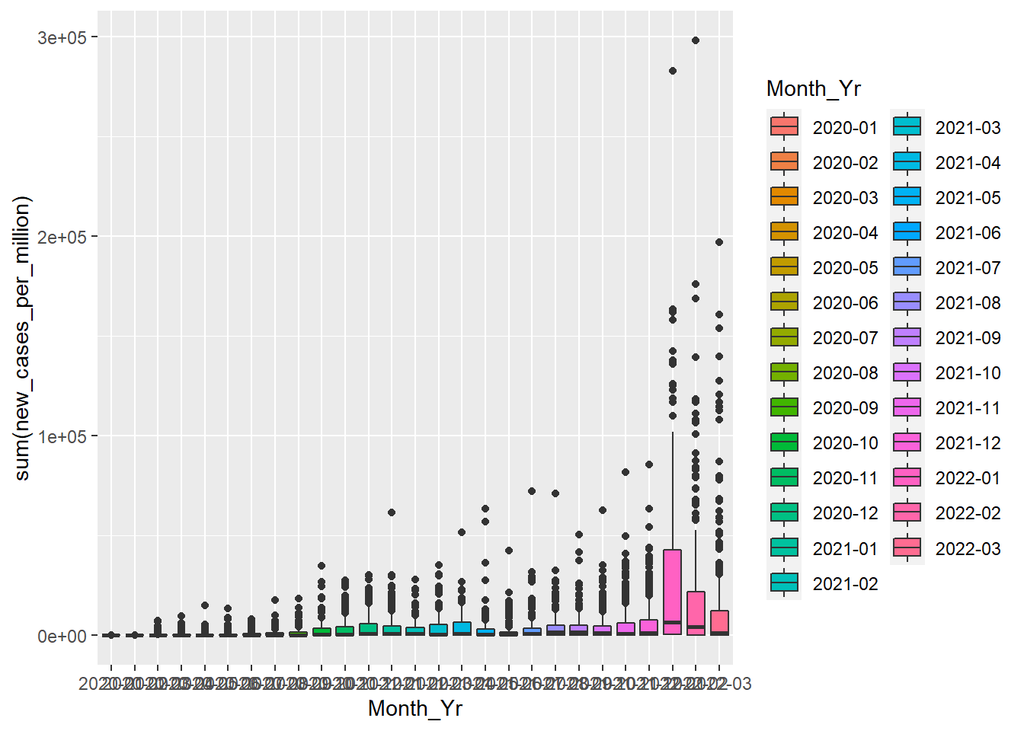

```r
df_q5a %>% ggplot(aes(Month_Yr,`sum(new_cases_per_million)`, fill=Month_Yr)) + geom_boxplot()
```

In the first graph (describes new cases per million/month) we can see the different world outbreaks of the pandemic: towards the end of 2020, the summer of 2021 and the last outbreak which occurred just a few months ago during the winter of 2022. Other than that, we can see that the overall new cases are scaling higher and higher over the period of 2020-2022 and even tough the slope of the trend is currently declining, the new cases per million/month is still higher than the average of the new cases per million/month of 2020-2021.

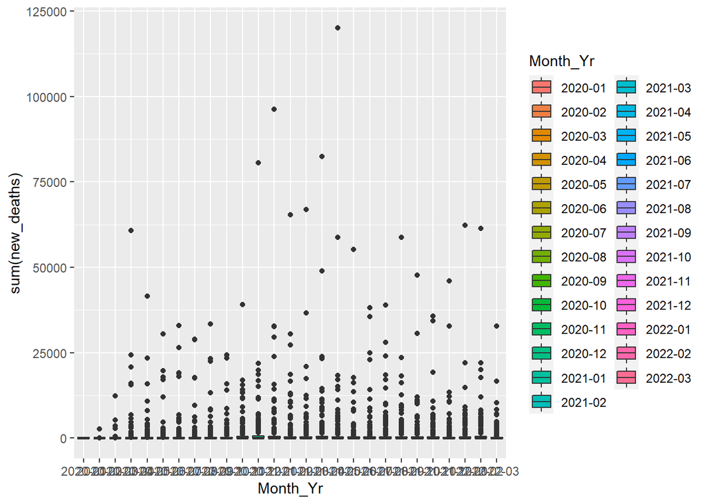

```r
df_q5b %>% ggplot(aes(Month_Yr,`sum(new_deaths)`, fill=Month_Yr)) + geom_boxplot()
```

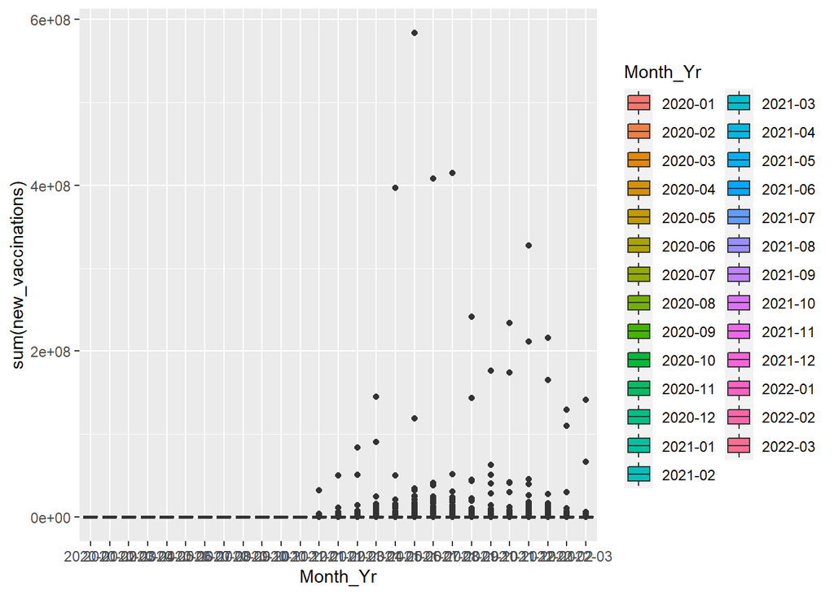

```r
df_q5c %>% ggplot(aes(Month_Yr,`sum(new_vaccinations)`, fill=Month_Yr)) + geom_boxplot()
```

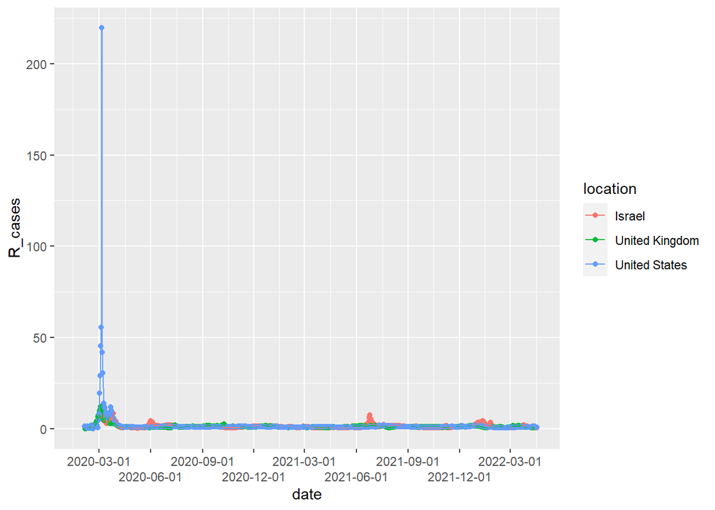

```r
#Here we calculate the R_cases
for(i in 1:length(df$date)){
  if (i<=7 || df$new_cases_smoothed[i-7] ==0 || is.na(df$new_cases_smoothed[i-7])){
    df$R_cases[i] = NA
  }
  else{
    df$R_cases[i] = df$new_cases_smoothed[i]/df$new_cases_smoothed[i-7]
  }
}
#Selecting the location and plot
list_of_locations = c("Israel", "United States", "United Kingdom")
df %>% select(location, R_cases, date) %>% filter(location %in% list_of_locations) %>% ggplot(aes(x = date, y= R_cases, colour=location)) + geom_point() + geom_line()+ scale_x_date(date_breaks="3 months")+guides(x = guide_axis(n.dodge=2))
```

```r
#Since there is a peak in the beginning for the united states, those jumps don't let us interpret very well.
```

In March of 2020 there was an outbreak in the United States which we see as the outliers the result in the peak on the left side of the graph. In order to learn more details we will use a cropped graph starting after the outbreak in the US.

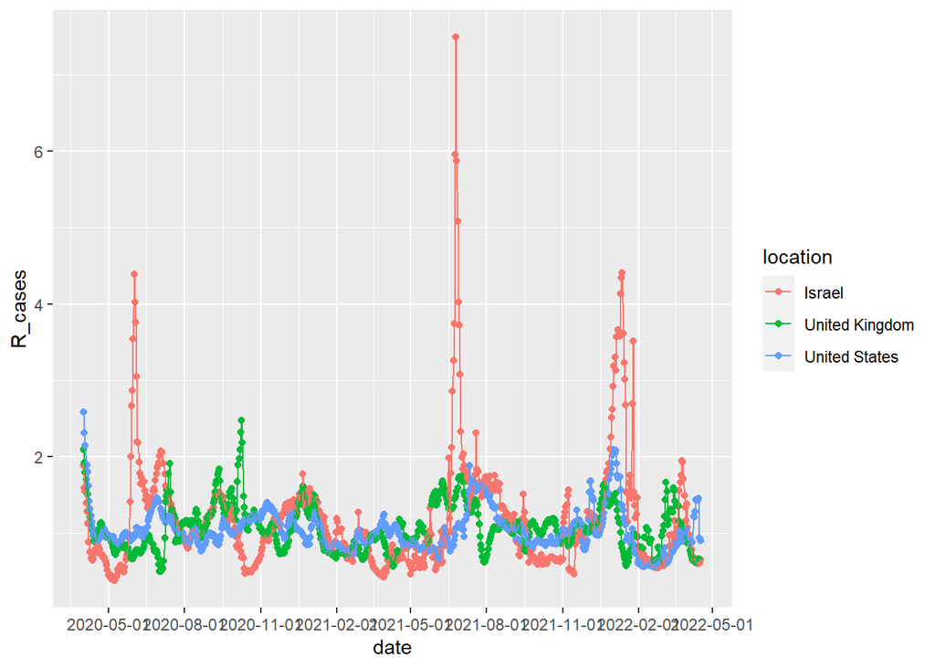

```r
#more accurate plot
df %>% select(location, R_cases, date) %>% filter(location %in% list_of_locations) %>% filter(date>='2020-04-01')  %>% ggplot(aes(x = date, y= R_cases, colour=location)) + geom_point() + geom_line()+ scale_x_date(date_breaks="3 months")
```

In this graph we can see in a clearer way the periods in which the pandemic spreads in each country. Especially we can identify the times of of the ways in Israel, first we see the decrease on the left, marking the end of the first wave when the government start to cancel some restrictions and to open businesses. Afterwards, we see the sharp jump starting in June, and the return of the restrictions during the summer until the second lockdown in September. Finally, in the end of 2021 we can identify the arrival of the Omicron variant. Based on this data we can assume that the other peaks of the graph represent the periods of stricter regulations in both the uk, like the first lockdown in england at the beginning of July, or the lockdown in October, or likewise in some states in the USA.

```r
#Here we make a table and calculate the days
table_spreading=df %>% select(location, R_cases, date) %>% filter(location %in% list_of_locations) %>% filter(R_cases>1) %>% count(location, sort= TRUE)
names(table_spreading)[names(table_spreading) == 'n'] <- 'number of days spreading'
table_spreading
```

```
##         location number of days spreading
## 1 United Kingdom                      443
## 2         Israel                      400
## 3  United States                      397
```

Here we have the table counting the days in which the R_cases was above 1, meaning counting the days in which the pandemic spread in each country.

7. In this questions we were asked to display the frequency of diffrenet variables for each country using a world map. We first rearranged the data frame and got rid of all the non country location rows:

```r
df_q7 = current %>% filter(!(continent==""))
```

And we split the data frame into 3 diffrenet data frames: each contains a diffrenet variable that we were requested to display:

```r
keeps1 <- c("iso_code","location","total_deaths_per_million")
df_q7a <- df_q7[keeps1]  #kept only the requested variables
tdpm <- joinCountryData2Map(df_q7a,joinCode="ISO3",nameJoinColumn="iso_code", nameCountryColumn="location")
```

```
## 224 codes from your data successfully matched countries in the map
## 5 codes from your data failed to match with a country code in the map
## 19 codes from the map weren't represented in your data
```

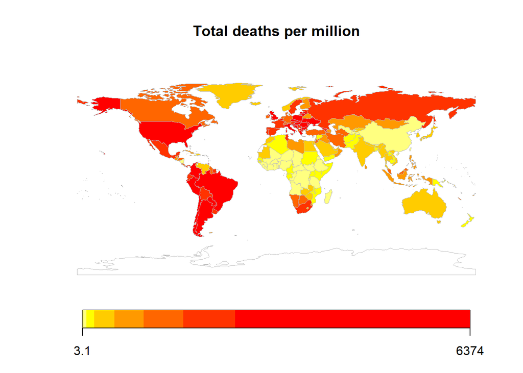

```r
mapCountryData(tdpm, nameColumnToPlot="total_deaths_per_million", mapTitle = "Total deaths per million")
```

```r
keeps2 <- c("iso_code","location","total_vaccinations_per_hundred")
df_q7b <- df_q7[keeps2]
tvph <- joinCountryData2Map(df_q7b,joinCode="ISO3",nameJoinColumn="iso_code", nameCountryColumn="location")
```

```
## 224 codes from your data successfully matched countries in the map
## 5 codes from your data failed to match with a country code in the map
## 19 codes from the map weren't represented in your data
```

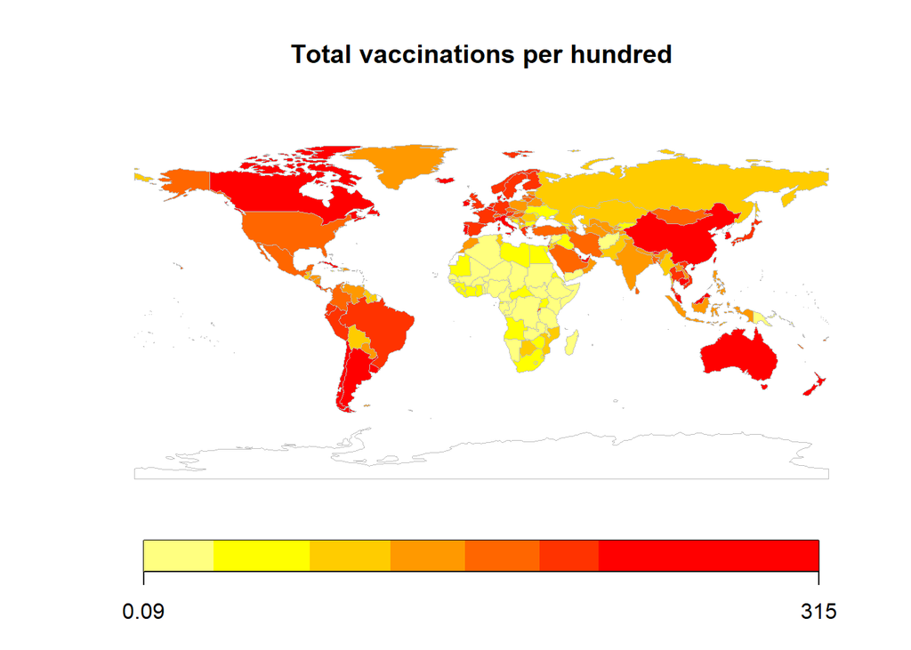

```r
mapCountryData(tvph, nameColumnToPlot="total_vaccinations_per_hundred",mapTitle = "Total vaccinations per hundred")
```

```r
dff <- subset(df, df$excess_mortality_cumulative_per_million>0)
dff2 <- dff[order(dff$iso_code, dff$date, decreasing = TRUE), ]
dff2 <- dff2[!duplicated(dff2$iso_code),]
keeps3 <- c("iso_code","location","excess_mortality_cumulative_per_million")
df_q7c <- dff2[keeps3]
emcp <- joinCountryData2Map(df_q7c,joinCode="ISO3",nameJoinColumn="iso_code", nameCountryColumn="location")
```

```
## 102 codes from your data successfully matched countries in the map
## 2 codes from your data failed to match with a country code in the map
## 141 codes from the map weren't represented in your data
```

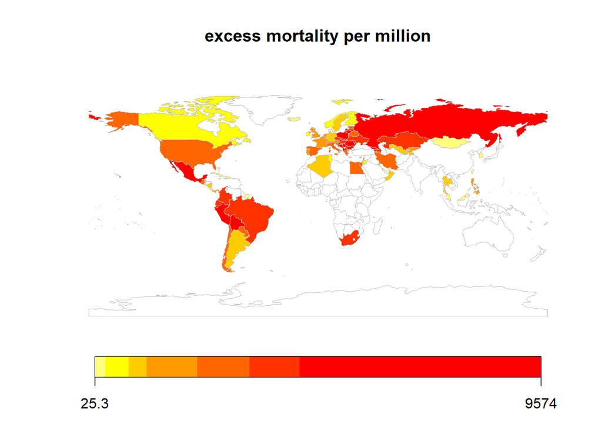

```r
mapCountryData(emcp, nameColumnToPlot="excess_mortality_cumulative_per_million", , mapTitle="excess mortality per million")
```

8. In this question we were required to recreate the “CCF” function without using it and run it on the “new_cases_smoothed” and “new_deaths_smoothed” variables. We first recreated the cross_corr function:

```r
cross_corr <- function(given_df, country, col1, col2){
  given_df=subset(given_df,location == country )   #keeping infomartion only about the given country
  given_df[is.na(given_df)]<-0        # making sure there aren't any na values.
  col1_vec<-as.numeric(as.list(t(given_df[,col1])))
  col2_vec<-as.numeric(as.list(t(given_df[,col2])))
  res_vec=vector(length=121)    #creating the result vector
  for (i in 1:60){         #calculating the correletions of the given vectors, each time using diffrenet indexes over the period of 120 days:
    res_vec[i+61]= cor(col1_vec[1:(length(col1_vec)-i)], col2_vec[(i+1):length(col2_vec)], use="complete.obs")
    res_vec[61-i]= cor(col1_vec[(i+1):length(col1_vec)], col2_vec[1:(length(col2_vec)-i)], use="complete.obs")
  }
  res_vec[60]= cor(given_df[,col1], given_df[,col2], use = "complete.obs")    #  adding the 60th index in the result vector
  return(res_vec)
}
```

Then we ran the function we built in a on the “new_cases_smoothed” and “new_deaths_smoothed” variables and plotted the resulted vector of values as a function of delta(going from -60 to 60):

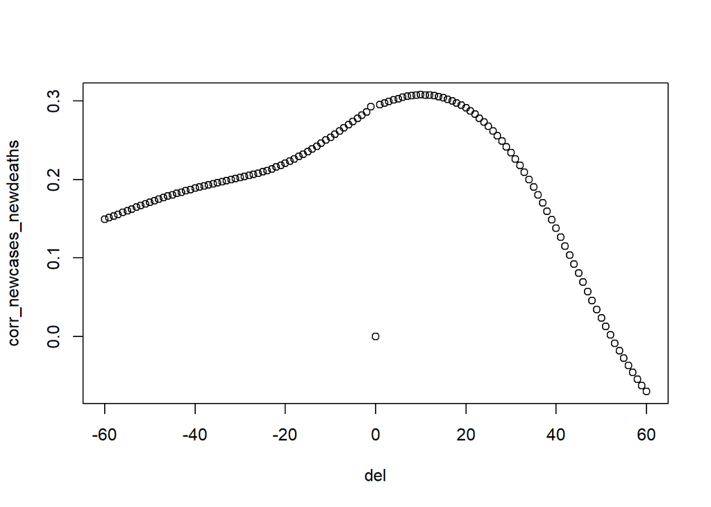

```r
corr_newcases_newdeaths<-cross_corr(df, "World", "new_cases_smoothed", "new_deaths_smoothed")
del<-(-60:60)
plot(del,corr_newcases_newdeaths)
```

9. In this question we are requested to calculate the death rate and analyze it against the ratio vaccination per hundred

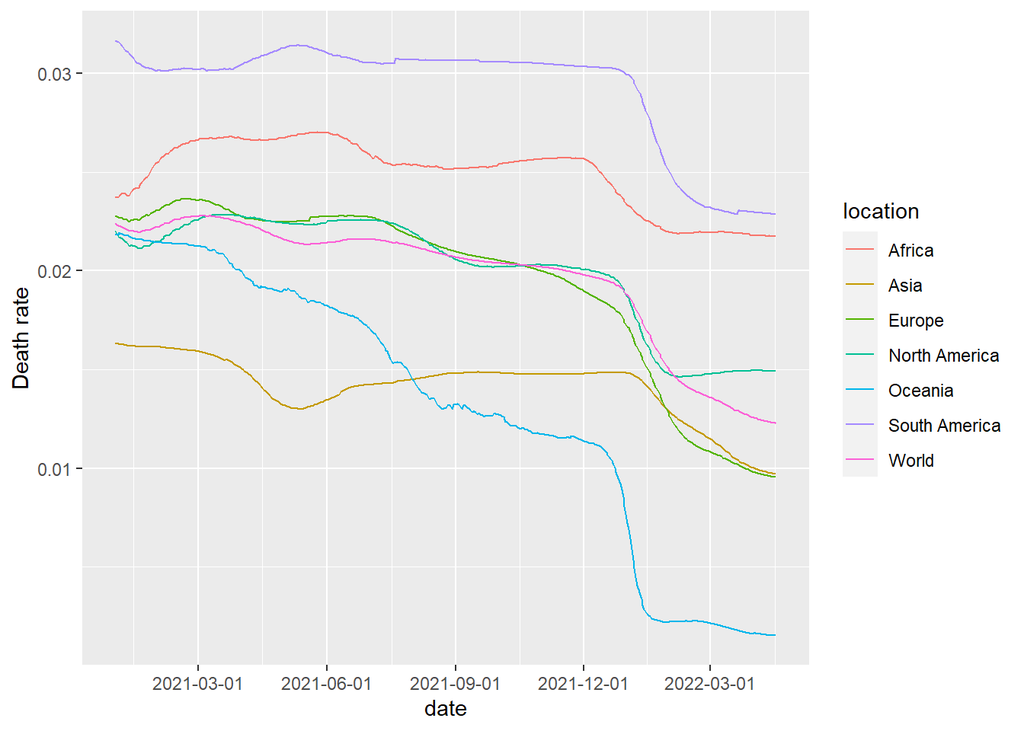

```r
#Here we create a column calculating the death rate
df$death_rate = df$total_deaths/df$total_cases
list_of_continents_and_world = c("Asia", "Africa", "Europe", "North America", "Oceania", "South America", "World")
#We plot for each continent and the world the death rate
df %>% select(location, date, death_rate) %>% filter(date>="2021-01-01") %>% filter(location %in% list_of_continents_and_world) %>% ggplot(aes(x=date, y=death_rate, colour=location)) + geom_line(size=0.5) +ylab("Death rate") + scale_x_date(date_breaks="3 months")
```

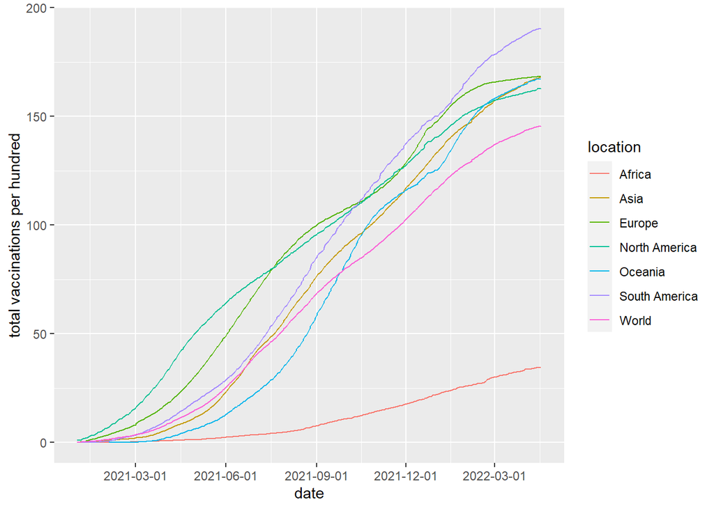

```r
df %>% select(location, date, total_vaccinations_per_hundred) %>% filter(date>="2021-01-01") %>% filter(location %in% list_of_continents_and_world) %>% ggplot(aes(x=date, y=total_vaccinations_per_hundred, colour=location)) + ylab("total vaccinations per hundred") + geom_line() + scale_x_date(date_breaks="3 months")
```

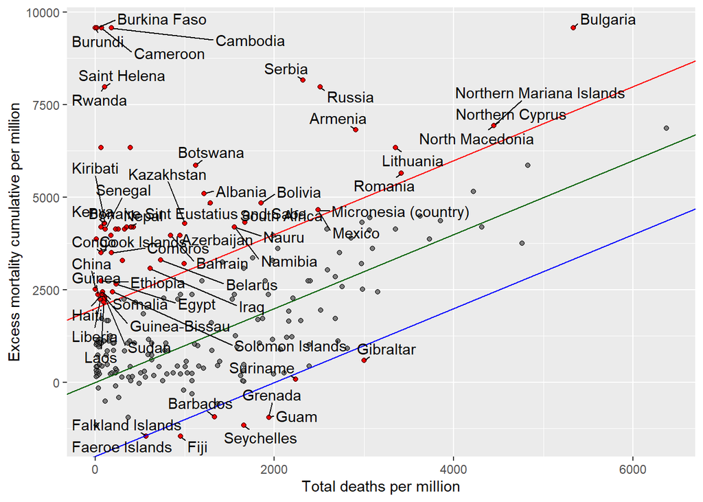

```r
current %>%select(total_deaths_per_million, excess_mortality_cumulative_per_million, location) %>%  ggplot(aes(total_deaths_per_million,excess_mortality_cumulative_per_million, label=location)) + geom_point(color = ifelse((abs((current$excess_mortality_cumulative_per_million - current$total_deaths_per_million))>2000), "red", "grey50"))+geom_point(shape=1,color="black")+geom_abline(intercept=0, slope=1, color="dark green") +
  geom_abline(intercept = 2000, slope=1, color="red") +
  geom_abline(intercept=-2000, slope=1, color="blue") +
  geom_text_repel(data=current[(abs((current$excess_mortality_cumulative_per_million - current$total_deaths_per_million))>2000) & (!(is.na(current$continent) | current$continent=="")),], min.segment.length = 0,  max.overlaps = 25, force=1) + ylab("Excess mortality cumulative per million") + xlab("Total deaths per million")
```

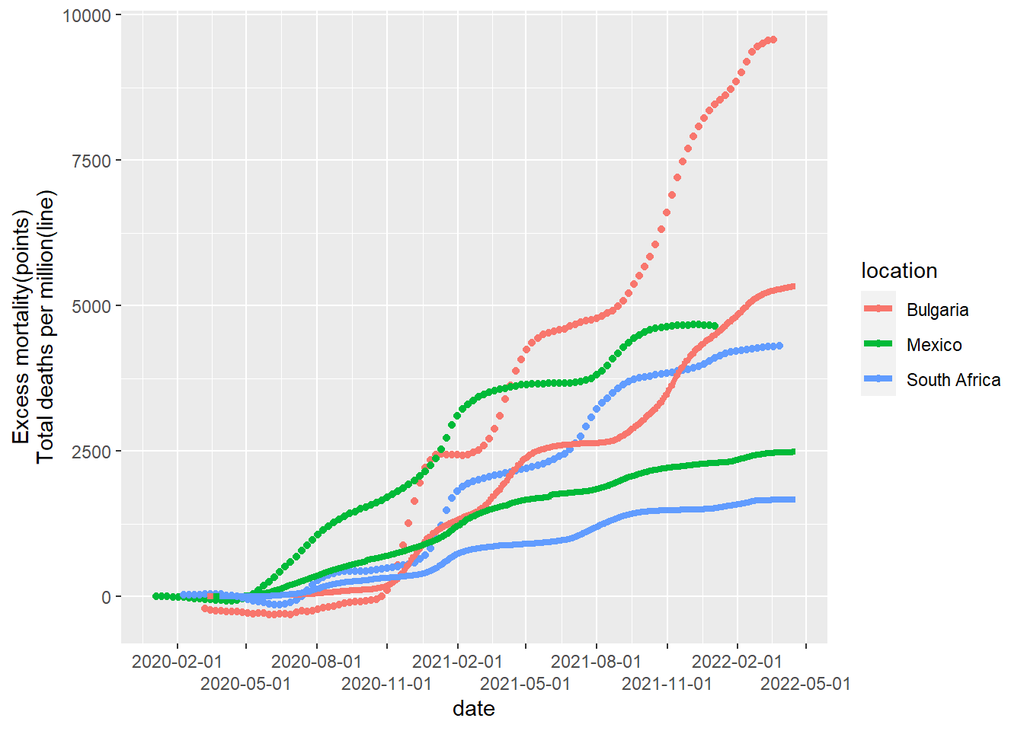

```r
#Here we make a list of countries that exceed the total deaths by at least 2000
new_list = current$location[((current$excess_mortality_cumulative_per_million - current$total_deaths_per_million)>2000)]
#We are asked to find countries with more than 50 documentations, We chose to find the most documents by excess mortality
most_documented = df %>% filter(!(continent=="")) %>%select(location, excess_mortality_cumulative_per_million, date) %>% filter(location %in% new_list) %>% group_by(location) %>% summarize(s=sum(!is.na(excess_mortality_cumulative_per_million))) %>% arrange(desc(s))
#Here we find the top 3 and than we plot
top_three_most_documented = most_documented$location[1:3]
df %>% select(location, date, excess_mortality_cumulative_per_million, total_deaths_per_million) %>%filter(location %in% top_three_most_documented) %>% ggplot(aes(x=date, y=excess_mortality_cumulative_per_million, colour=location)) + geom_point()+geom_line(aes(x=date, y=excess_mortality_cumulative_per_million,color=location), size=1.5, shape=17) + geom_line(aes(x=date, y=total_deaths_per_million,color=location),size=1.5) +ylab("Excess mortality(points)\nTotal deaths per million(line)") + scale_x_date(date_breaks="3 months")+guides(x = guide_axis(n.dodge=2))
```

First we calcualted all the countries under the needed condition, and than we found out the 3 most documented in our dataframe. We can identify the periods in which most deaths were not explained by the pandemic (when both lines starts to diverge for each country: Mexico around may, Bulgaria and south africa around november) amd we can spot that both ratios are pretty correlated with each other. Similarly, we can find the other periods in which more deaths were not explained by the pandemic by looking spotting the periods in which there was a big diffrence between the two lines.

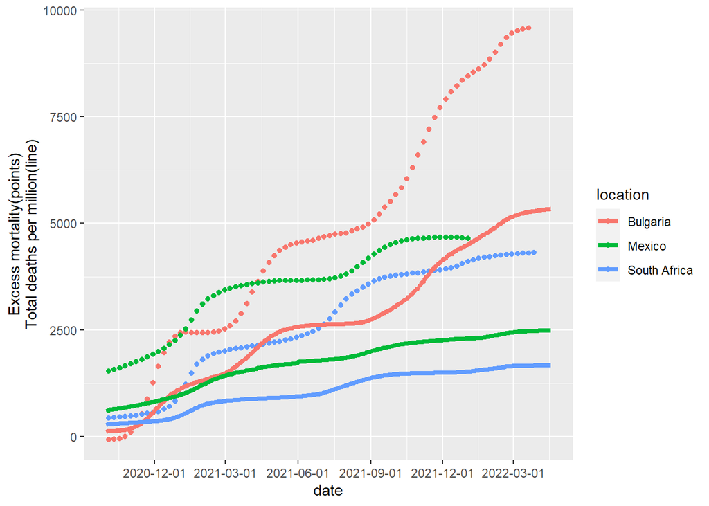

```r
#more accurate:
df %>% select(location, date, excess_mortality_cumulative_per_million, total_deaths_per_million) %>%filter(location %in% top_three_most_documented)%>%filter(date>="2020-10-01") %>% ggplot(aes(x=date, y=excess_mortality_cumulative_per_million, colour=location)) + geom_point()+geom_line(aes(x=date, y=excess_mortality_cumulative_per_million,color=location), size=1.5, shape=17) + geom_line(aes(x=date, y=total_deaths_per_million,color=location),size=1.5) +ylab("Excess mortality(points)\nTotal deaths per million(line)")+scale_x_date(date_breaks="3 months")
```

[output not shown]